```python
%matplotlib inline
```

# Multi-dimensional scaling

Utilizaremos el dataset de caras de Olivetti de AT&T para aprender embeddings en un espacio de 2 dimensiones. El dataset tiene 10 imágenes de 64x64 por persona, cada imagen adquirida con diferentes expresiones faciales o condiciones de iluminación.

Al aplicar MDS pretendemos que se preserven los patrones de los datos de manera que imágenes de caras de la misma persona estén cerca, pero lejos de las caras del resto de personas.

Para que se pueda ver correctamente, se cogerán caras de únicamente 4 personas.

Para ver los diferentes parámetros de entrada del algoritmo MDS:

https://scikit-learn.org/stable/modules/generated/sklearn.manifold.MDS.html

```python
from sklearn.manifold import MDS
from matplotlib import pyplot as plt
import sklearn.datasets as dt
import seaborn as sns
import numpy as np
from sklearn.metrics.pairwise import manhattan_distances, euclidean_distances
from matplotlib.offsetbox import OffsetImage, AnnotationBbox
```

Antes de aplicar MDS, escribiremos un pequeña función, mapeaDatos(), que representa los puntos transformados en 2D, con el mismo color para los puntos de la misma persona. En la segunda figura representa la imagen de cada cara sobre el gráfico en el espacio de baja dimensionalidad.

```python
def mapeaDatos(Y, X, y, titulo):

    # Plot the embedding, colored according to the class of the points
    fig = plt.figure(2, (15,6))
    ax = fig.add_subplot(1,2,1)
    ax = sns.scatterplot(x=Y[:, 0], y=Y[:, 1],
                         hue=y, palette=['r', 'g', 'b', 'c'])

    # Add the second plot
    ax = fig.add_subplot(1,2,2)
    # Plot the points again
    plt.scatter(Y[:, 0], Y[:, 1])

    # Annotate each point by its corresponding face image
    for x, ind in zip(X, range(Y.shape[0])):
        im = x.reshape(64,64)
        imagebox = OffsetImage(im, zoom=0.3, cmap=plt.cm.gray)
        i = Y[ind, 0]
        j = Y[ind, 1]
        ab = AnnotationBbox(imagebox, (i, j), frameon=False)
        ax.add_artist(ab)
    plt.title(titulo)
    plt.show()
```

Elegimos las caras de 4 personas:

```python
caras = dt.fetch_olivetti_faces()
X_caras = caras.data
y_caras = caras.target
ind = y_caras < 4
X_caras = X_caras[ind,:]
y_caras = y_caras[ind]
print(X_caras.shape)
```

```
(40, 4096)
```

Vamos a aplicar MDS de manera manual, paso por paso.

### 1.- Matriz de proximidad

Implementa una función que calcule la función de proximidad S mediante funciones numpy.

```python
dist = []
for c in X_caras:
    d = [np.sqrt(np.sum(np.square(c-c2))) for c2 in X_caras]
    print(d,"\n")
    dist.append(d)
```

[output not shown]

[output cut: 53 more lines]

Muestra la matriz de proximidad.

```python
dist = np.array(dist)
```

```python
dist
```

```
array([[ 0.       , 12.699108 ,  6.5857997, ..., 11.679333 , 12.403604 ,
        11.297996 ],
       [12.699108 ,  0.       , 12.025273 , ..., 13.545745 , 12.983825 ,
         9.566442 ],
       [ 6.5857997, 12.025273 ,  0.       , ..., 12.059173 , 12.847783 ,
        11.259902 ],
       ...,
       [11.679333 , 13.545745 , 12.059173 , ...,  0.       ,  9.108186 ,
        11.104076 ],
       [12.403604 , 12.983825 , 12.847783 , ...,  9.108186 ,  0.       ,
         9.447212 ],
       [11.297996 ,  9.566442 , 11.259902 , ..., 11.104076 ,  9.447212 ,
         0.       ]], dtype=float32)
```

Comprueba el resultado calculando la misma matriz mediante la función de sklearn `euclidean_distances`. Representa el resultado y comprueba que tu matriz anterior esté bien calculada.

```python
distancias = euclidean_distances(X_caras)
S = distancias
```

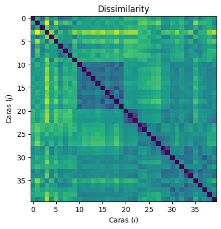

```python
plt.imshow(S)

plt.title("Dissimilarity")
plt.xlabel("Caras ($i$)")
plt.ylabel("Caras ($j$)")
```

### 2.- Matriz de centrado

Para asegurar una única solución al problema, debemos centrar los datos de manera que la suma de los valores de todas las filas (y columnas) sea igual a 0. Para ello, construye la matriz de centrado H teniendo en cuenta pesos uniformes para cada cara. Puedes utilizar las funciones numpy `identity`y `full`.

```python
# Cálculo de la matriz de centrado
m = np.ones(shape=(len(S),1))*(1/len(S))

h = np.identity(m.shape[0]) - np.full(shape=(m.shape[0],m.shape[0]),fill_value=m)
```

Representa la matriz de centrado.

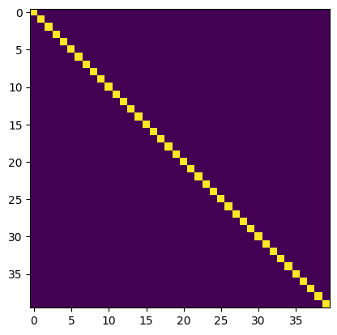

```python
plt.imshow(h)
```

### 3.- Cálculo de la matriz F.

Calcula y representa la matriz F. Puedes utilizar las funciones numpy `matmul` y `transpose`.

```python
f = -0.5* (np.dot(np.dot(h,S),h.T))
```

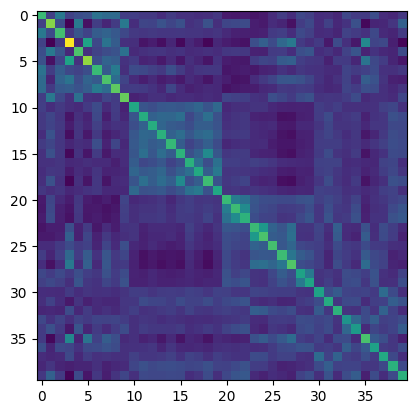

```python
plt.imshow(f)
```

### 4.- Descomposición en valores y vectores propios.

Obtén los autovalores (Lambda) y los autovectores (U) de la matriz F. Puedes utilizar la función numpy `linalg.eig`.

```python
# Obtenemos valores y vectores propios
w,v = np.linalg.eig(f)
```

```python
# Valores propios
print("Eigenvectors: ",v,"\n")
```

```
Eigenvectors:  [[-0.06248934 -0.30979778 -0.084448   ...  0.20791521  0.17829022
   0.02862666]
 [ 0.16107116 -0.06001408 -0.30938121 ...  0.06644269 -0.17132026
  -0.02954283]
 [-0.03843689 -0.24706817 -0.12458734 ... -0.10058337  0.06508273
  -0.14393062]
 ...
 [-0.0320875   0.08172571  0.13374632 ... -0.02917809  0.12441121
   0.03495982]
 [ 0.11724441  0.08466888  0.07038352 ...  0.01450629  0.13995445
   0.29252054]
 [ 0.12933321  0.02133918 -0.19950485 ... -0.20485114  0.07313829
   0.26299266]]
```

```python
# Vectores propios
print("Eigenvalues: ",w,"\n")
```

```
Eigenvalues:  [3.01874410e+01 2.10556594e+01 1.92796498e+01 1.04631613e+01
 8.74049694e+00 8.44556182e+00 7.84517687e+00 9.83661887e-16
 6.79701336e+00 5.80551515e+00 5.65111493e+00 5.00974409e+00
 4.89193672e+00 4.79833910e+00 1.72106230e+00 1.83427666e+00
 1.92304648e+00 1.90489887e+00 2.04685575e+00 2.12129053e+00
 4.37710385e+00 4.34571390e+00 4.12968080e+00 2.54514718e+00
 3.93765461e+00 3.84412864e+00 3.79240105e+00 2.73025441e+00
 2.74620652e+00 3.65760632e+00 2.89504686e+00 3.53849328e+00
 3.43403038e+00 3.35273631e+00 2.99189398e+00 3.02228615e+00
 3.25884970e+00 3.23568557e+00 3.09213699e+00 3.14116284e+00]
```

### 5.- Obtención de la matriz Y (baja dimensionalidad).

Calcula la matriz Y y representa los resultados del método manual y del método sklearn (función `MDS`) utilizando la función `mapeaDatos`.

```python
# Obtención de la matriz Y
Lambda = w
U = v
Y = np.matmul(np.sqrt(np.linalg.inv(np.diag(m[:,0]))),np.matmul(U,np.sqrt(np.diag(Lambda))))
```

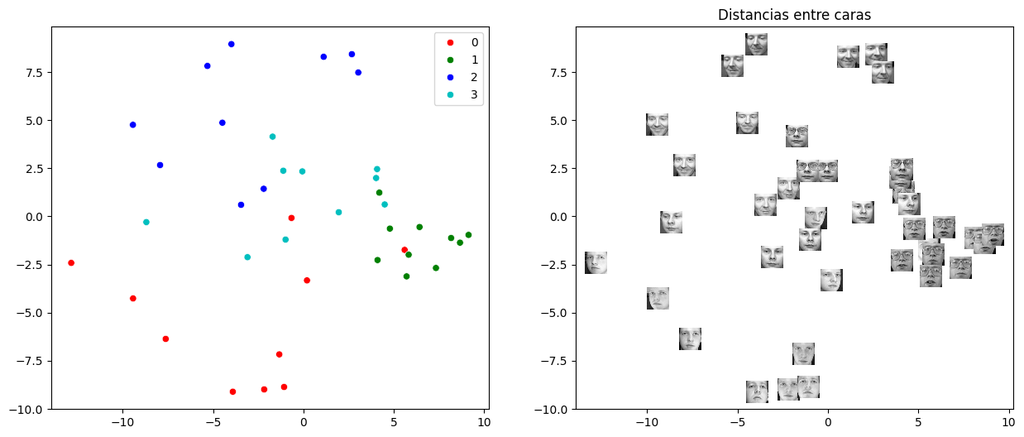

```python
# Representación de los datos
mapeaDatos(Y,X_caras,y_caras,"Distancias entre caras")
```

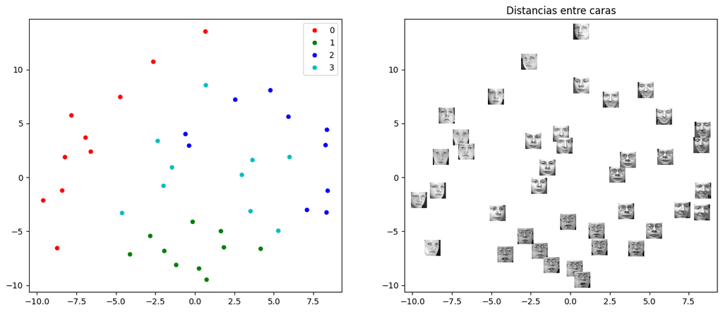

```python
# Utilizando MDS de sklearn
mds = MDS(n_components=2, dissimilarity='precomputed')

X_reduced = mds.fit_transform(distancias)


mapeaDatos(X_reduced,X_caras,y_caras,"Distancias entre caras")
```

¿Qué ocurre? ¿A qué puede ser debido?

Se puede deber a que en la librería sklearn se utilizan unos parámetros ya estudiados que funcionen mejor de manera general.

### 6.- Bondad (goodness-of-fit)

Para obtener la bondad de la proyección, podemos calcular el stress. Sin embargo, para ello necesitamos las distancias por pares de la proyección. A partir de la matriz Y, representa las coordenadas proyectadas utilizando la fórmula de Euler.

```python
proj_dist = np.zeros(S.shape)

for i in range(len(S)):
    for j in range(len(S)):
        proj_dist[i,j] = np.sqrt((Y[j,0]-Y[i,0])**2 + (Y[j,1]-Y[i,1])**2)
```

Obtén el stress de Kruskall de la proyección Y. Según la tabla vista en teoría, ¿tendríamos una buena proyección?

```python
num = 0
den = 0
den2 = 0
meanS =np.mean(S)
for i in range(len(S)):
    for j in range(len(S)):
        if i!=j:
            num+=(proj_dist[i,j]-S[i,j])**2
            den +=(S[i,j])**2

stress = np.sqrt(num/den)
stress
```

```
0.3216678361878553
```

En este caso, es una mala proyección al ser mayor a 0.2

Compara este valor con el stress obtenido con el algoritmo MDS.

```python
stress = mds.stress_
print("Estrés del MDS:", stress)
```

```
Estrés del MDS: 7379.068225177382
```

Representa las distancias proyectadas vs las distancias originales. ¿El resultado es bueno? ¿Por qué?

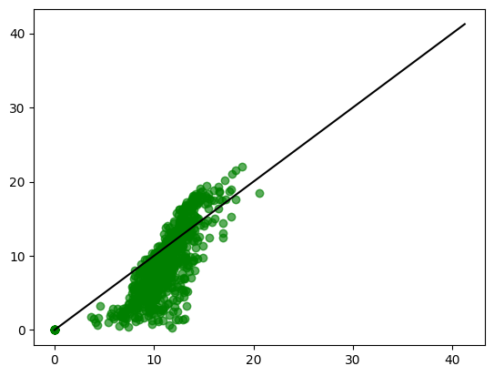

```python
plt.scatter(S,proj_dist,label="Projected vs original", alpha=0.4, color = "green")
plt.plot(2*np.max(S)*np.array([0,1]),2*np.max(S)*np.array([0,1]), color ="black")
```

No se ajustan demasiado bien, vemos como las distancias proyectadas no se corresponden bien con las originales.

### 7. Número de componentes

Uno de los hiper-parámetros más importantes relacionados con MDS es el tamaño del espacio de bajas dimensiones. Este factor es relevante si aplicamos MDS como preprocesado para reducir la dimensionalidad. ¿Cuantas dimensiones cogemos sin perder demasiada información?

Para ello, representa el gráfico de sedimentación. Ejecuta MDS con diferente número de componentes (i.e. de 1 a 20) y representa el valor del `stress` en cada caso.

¿Cuantas componentes escogerías?

[output not shown]

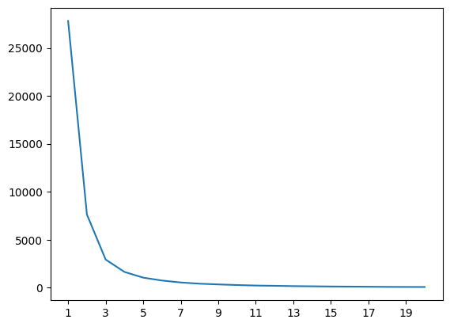

```python
stress = []

max_range = 21
for dim in range(1,max_range):
    mds = MDS(n_components=dim,dissimilarity="precomputed",normalized_stress = "auto",)
    pts = mds.fit_transform(distancias)
    stress.append(mds.stress_)

plt.plot(range(1,max_range),stress)
plt.xticks(range(1,max_range,2))
```

Por la regla del codo, utilizaría entre 3 y 5 dimensiones, dado a que es donde se experimenta la mayor bajada de la gráfica, y a partir de ahí sigue bajando pero de manera suave, entonces no se gana tanta precisión a la hora de calcular las distancias.

## Ejercicios extra utilizando sklearn

#### Ejercicio 1 MDS no métrico

Resuelve el problema utilizando "Non-metric MDS". ¿Observas diferencias en el resultado? ¿Qué stress obtienes?

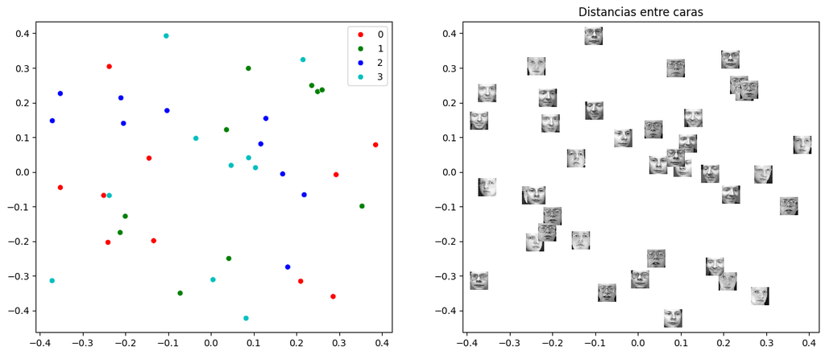

```python
Non_metric_MDS = MDS(n_components=5, dissimilarity="precomputed", metric=False)
X_reduced = Non_metric_MDS.fit_transform(distancias)


mapeaDatos(X_reduced,X_caras,y_caras,"Distancias entre caras")
```

```python
stress = Non_metric_MDS.stress_
print("Estrés del MDS:", stress)
```

```
Estrés del MDS: 10.31997808591877
```

Al ahora solo tener en cuenta distancias relativas, es posible que esta relación de orden se preserve mejor que el intentar guardar las distancias al uso. Por eso es posible que el estrés salga mejor al quitar la métrica.

#### Ejercicio 2 Aplica el algoritmo MDS al dataset `RandomSurveyData`

`RandomSurveyData` contiene los resultados de una encuesta con 15 preguntas diferentes. Las respuestas pueden ser: strongly disagree, disagree, neutral, agree, strongle agree. Aplica el algoritmo **MDS no métrico** con 2 componentes y representa el resultado. Aplica el algoritmo de clustering `kmeans` y compara los resultados obtenidos poniendo en color los puntos de cada muestra según el cluster al que corresponde.

```python
import pandas as pd
from sklearn.manifold import MDS
from matplotlib import pyplot as plt
import sklearn.datasets as dt
import seaborn as sns
import numpy as np
from sklearn.metrics.pairwise import manhattan_distances, euclidean_distances
from matplotlib.offsetbox import OffsetImage, AnnotationBbox

df = pd.read_csv("./RandomSurveyData.csv")
```

```python
df.head()
```

|  | P1 | P2 | P3 | P4 | P5 | P6 | P7 | P8 | P9 | P10 | P11 | P12 | P13 | P14 | P15 | id |
| --- | --- | --- | --- | --- | --- | --- | --- | --- | --- | --- | --- | --- | --- | --- | --- | --- |
| 0 | Strongly Disagree | Strongly Agree | Disagree | Neutral | Disagree | Agree | Neutral | Agree | Neutral | Neutral | Agree | Neutral | Disagree | Neutral | Disagree | Respondent #1 |
| 1 | Strongly Disagree | Agree | Agree | Neutral | Disagree | Neutral | Disagree | Agree | Neutral | Disagree | Disagree | Agree | Strongly Disagree | Disagree | Disagree | Respondent #3 |
| 2 | Agree | Agree | Neutral | Neutral | Disagree | Agree | Disagree | Neutral | Disagree | Neutral | Strongly Disagree | Agree | Strongly Disagree | Disagree | Disagree | Respondent #4 |
| 3 | Disagree | Agree | Neutral | Neutral | Neutral | Disagree | Disagree | Agree | Neutral | Neutral | Strongly Disagree | Neutral | Strongly Disagree | Disagree | Disagree | Respondent #5 |
| 4 | Strongly Disagree | Strongly Agree | Strongly Agree | Agree | Strongly Disagree | Strongly Agree | Agree | Agree | Disagree | Disagree | Strongly Disagree | Neutral | Neutral | Agree | Disagree | Respondent #6 |

```python
mapping = {
    "Strongly Disagree": 1,
    "Disagree": 2,
    "Neutral": 3,
    "Agree": 4,
    "Strongly Agree": 5
}
df_num=df.copy()

for col in df.columns[:-1]:
    df_num[col] = df[col].map(mapping)
```

```python
from sklearn.cluster import KMeans
kmeans = KMeans(5)

# Aplicamos KMeans a las coordenadas reducidas
kmeans.fit(df_num.iloc[:,:-1])

# Obtenemos las etiquetas de cluster asignadas a cada punto
labels = kmeans.labels_
```

```python
distancias = euclidean_distances(df_num.iloc[:,:-1])
```

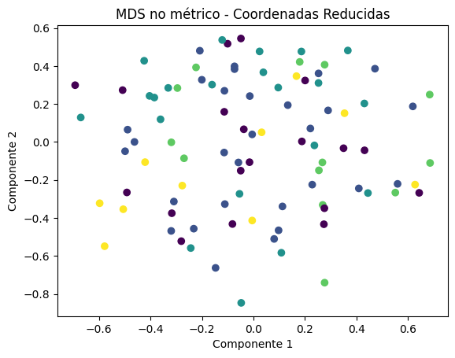

```python
mds_non_metric = MDS(n_components=2, dissimilarity="precomputed", metric=False)

# Aplicamos MDS no métrico para obtener las coordenadas reducidas
coords_reduced = mds_non_metric.fit_transform(distancias)

# Representamos el resultado
plt.scatter(coords_reduced[:, 0], coords_reduced[:, 1], c=labels)
plt.title('MDS no métrico - Coordenadas Reducidas')
plt.xlabel('Componente 1')
plt.ylabel('Componente 2')
plt.show()
```

Vemos como si no utilizamos una métrica, Kmeans que se basa en esto mismo no combina bien con un método basado en orden que además reduce la dimensionalidad. En cambio, si utilizamos MDS métrico, los resultados varían mucho:

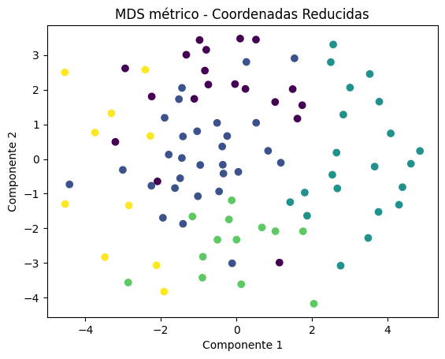

```python
mds_metric = MDS(n_components=2, dissimilarity="precomputed")

# Aplicamos MDS no métrico para obtener las coordenadas reducidas
coords_reduced = mds_metric.fit_transform(distancias)

# Representamos el resultado
plt.scatter(coords_reduced[:, 0], coords_reduced[:, 1], c=labels)
plt.title('MDS métrico - Coordenadas Reducidas')
plt.xlabel('Componente 1')
plt.ylabel('Componente 2')
plt.show()
```

Al intentar MDS preservar las distancias originales, y por otro lado Kmeans utilizar distancias para agrupar, vemos como el resultado queda muy parejo. Puntos que kmeans clasificaba como del mismo cluster quedan basante juntos con respecto a la representación en el espacio reducido de 2 dimensiones.